# TU060 - Math 9102 – PSI - Assignment

#### 3.1.2.2 Step 2 Select and run the T-Test for Gender

```r
############
# PART 1: T-Test for Gender
############
# -------------- Conduct the t-test --------------- #
#Conduct the t-test from package stats
#In this case we can use the var.equal = FALSE option to specify not equal variances.

tbl_test_result <- data.frame()
tbl_test_effectsize <- data.frame()

# Brittle code here, hardcoded variable of interest index.
for (n in c(1, 4, 5, 6)) {
  ## start
  variable    <- colnames(tbl_sperf_sex_nat_diff)[n]
  test_result <- stats::t.test(tbl_sperf_sex_nat_diff[, n] ~ as.factor(tbl_sperf_sex_nat_diff$GENDER), var.equal = FALSE) %>%
          broom::tidy() %>%
          as.data.frame()

  # Build output table
  row.names(test_result) <- variable
  tbl_test_result        <- rbind(tbl_test_result, test_result)

  #---------- Calculate Cohens D Effect size ---------- #
  effcd <- round(effectsize::t_to_d(t = test_result$statistic, test_result$parameter), 2)

  #---------- Calculate Eta Squared Effect size ---------- #
  #Eta squared calculation
  effes <- round((test_result$statistic * test_result$statistic) / ((test_result$statistic * test_result$statistic) + (test_result$parameter)), 3)

  # Build output table
  tbl_merged_effectsize            <- merge(effcd, effes)
  row.names(tbl_merged_effectsize) <- variable
  tbl_test_effectsize              <- rbind(tbl_test_effectsize, tbl_merged_effectsize)

}

## tidy up column names
colnames(tbl_test_result)[1] <- 'mean.diff.est'
colnames(tbl_test_result)[2] <- paste('mean', levels(as.factor(tbl_sperf_sex_nat_diff$GENDER))[1], sep = ".")
colnames(tbl_test_result)[3] <- paste('mean', levels(as.factor(tbl_sperf_sex_nat_diff$GENDER))[2], sep = ".")
colnames(tbl_test_result)[6] <- 'df'
#P-value is your probability - in this case every result was statiscally significant @ P < .05*

# -------------- Pretty Print Test statistics --------------- #
tbl_test_result %>%
        kbl(caption = "Summary of T-Test Statistics for the Male and Female student Groups") %>%
        kable_styling(bootstrap_options = c("striped", "hover"))
```

(#tab:section 3 t test part 1)Summary of T-Test Statistics for the Male and Female student Groups

|  | mean.diff.est | mean.F | mean.M | statistic | p.value | df | conf.low | conf.high | method | alternative |
| --- | --- | --- | --- | --- | --- | --- | --- | --- | --- | --- |
| MAT_S11 | -4.0231017 | 61.93238 | 65.95548 | -19.073300 | 0.0000000 | 11353.66 | -4.436558 | -3.6096454 | Welch Two Sample t-test | two.sided |
| BIO_S11 | -2.8336346 | 62.26829 | 65.10193 | -14.221044 | 0.0000000 | 11382.97 | -3.224212 | -2.4430576 | Welch Two Sample t-test | two.sided |
| ENG_S11 | -0.5894605 | 61.45112 | 62.04058 | -2.281401 | 0.0225434 | 11239.88 | -1.095924 | -0.0829972 | Welch Two Sample t-test | two.sided |
| G_SC | -2.4126178 | 161.27821 | 163.69083 | -5.777472 | 0.0000000 | 11207.16 | -3.231169 | -1.5940669 | Welch Two Sample t-test | two.sided |

```r
# -------------- Pretty Print Test Effect size --------------- #
tbl_test_effectsize %>%
        kbl(caption = "Summary of T-Test Effectsize for the Male and Female student Groups") %>%
        kable_styling(bootstrap_options = c("striped", "hover"))
```

(#tab:section 3 t test part 1)Summary of T-Test Effectsize for the Male and Female student Groups

|  | d | CI | CI_low | CI_high | y |
| --- | --- | --- | --- | --- | --- |
| MAT_S11 | -0.36 | 0.95 | -0.40 | -0.32 | 0.031 |
| BIO_S11 | -0.27 | 0.95 | -0.30 | -0.23 | 0.017 |
| ENG_S11 | -0.04 | 0.95 | -0.08 | -0.01 | 0.000 |
| G_SC | -0.11 | 0.95 | -0.15 | -0.07 | 0.003 |

#### 3.1.2.3 Step 3 select and run the T-Test for School Nature

```r
############
# PART 2: T-Test for School Nature
############
# -------------- Conduct the t-test --------------- #
#Conduct the t-test from package stats
#In this case we can use the var.equal = FALSE option to specify not equal variances.

tbl_test_result <- data.frame()
tbl_test_effectsize <- data.frame()

# Brittle code here, hardcoded variable of interest index.
for (n in c(1, 4, 5, 6)) {
  ## start
  variable    <- colnames(tbl_sperf_sex_nat_diff)[n]
  test_result <- stats::t.test(tbl_sperf_sex_nat_diff[, n] ~ as.factor(tbl_sperf_sex_nat_diff$SCHOOL_NAT), var.equal = FALSE) %>%
          broom::tidy() %>%
          as.data.frame()

  # Build output table
  row.names(test_result) <- variable
  tbl_test_result        <- rbind(tbl_test_result, test_result)

  #---------- Calculate Cohens D Effect size ---------- #
  effcd <- round(effectsize::t_to_d(t = test_result$statistic, test_result$parameter), 2)

  #---------- Calculate Eta Squared Effect size ---------- #
  #Eta squared calculation
  effes <- round((test_result$statistic * test_result$statistic) / ((test_result$statistic * test_result$statistic) + (test_result$parameter)), 3)

  # Build output table
  tbl_merged_effectsize            <- merge(effcd, effes)
  row.names(tbl_merged_effectsize) <- variable
  tbl_test_effectsize              <- rbind(tbl_test_effectsize, tbl_merged_effectsize)

}

## tidy up column names
colnames(tbl_test_result)[1] <- 'mean.diff.est'
colnames(tbl_test_result)[2] <- paste('mean', levels(as.factor(tbl_sperf_sex_nat_diff$SCHOOL_NAT))[1], sep = ".")
colnames(tbl_test_result)[3] <- paste('mean', levels(as.factor(tbl_sperf_sex_nat_diff$SCHOOL_NAT))[2], sep = ".")
colnames(tbl_test_result)[6] <- 'df'
#P-value is your probability - in this case every result was statiscally significant @ P < .05*

# -------------- Pretty Print Test statistics --------------- #
tbl_test_result %>%
        kbl(caption = "Summary of T-Test Statistics for the Private and Public student Groups") %>%
        kable_styling(bootstrap_options = c("striped", "hover"))
```

(#tab:section 3 t test part 2)Summary of T-Test Statistics for the Private and Public student Groups

|  | mean.diff.est | mean.PRIVATE | mean.PUBLIC | statistic | p.value | df | conf.low | conf.high | method | alternative |
| --- | --- | --- | --- | --- | --- | --- | --- | --- | --- | --- |
| MAT_S11 | 5.44578 | 66.88591 | 61.44013 | 26.36858 | 0 | 12408.75 | 5.040958 | 5.850602 | Welch Two Sample t-test | two.sided |
| BIO_S11 | 4.51852 | 66.07890 | 61.56038 | 23.06953 | 0 | 12363.82 | 4.134594 | 4.902447 | Welch Two Sample t-test | two.sided |
| ENG_S11 | 11.21289 | 67.08271 | 55.86983 | 48.22888 | 0 | 11971.48 | 10.757162 | 11.668610 | Welch Two Sample t-test | two.sided |
| G_SC | 11.68779 | 168.21584 | 156.52805 | 29.13527 | 0 | 12345.14 | 10.901460 | 12.474117 | Welch Two Sample t-test | two.sided |

```r
# -------------- Pretty Print Test Effect size --------------- #
tbl_test_effectsize %>%
        kbl(caption = "Summary of T-Test Effectsize for the Private and Public student Groups") %>%
        kable_styling(bootstrap_options = c("striped", "hover"))
```

(#tab:section 3 t test part 2)Summary of T-Test Effectsize for the Private and Public student Groups

|  | d | CI | CI_low | CI_high | y |
| --- | --- | --- | --- | --- | --- |
| MAT_S11 | 0.47 | 0.95 | 0.44 | 0.51 | 0.053 |
| BIO_S11 | 0.41 | 0.95 | 0.38 | 0.45 | 0.041 |
| ENG_S11 | 0.88 | 0.95 | 0.84 | 0.92 | 0.163 |
| G_SC | 0.52 | 0.95 | 0.49 | 0.56 | 0.064 |

#### 3.1.2.4 Reporting gender difference with Cohen’s D

An independent-samples t-test was conducted to compare highschool maths final scores for students who are male or female. A statistically significant result was found (M = 65.96, SD = 12.06 for Male students, M = 61.93, SD = 11.17 for female students), (t(11353) = -19.07, p < .001). Cohen’s d also indicated a small effect size (d = - 0.36).

An independent-samples t-test was conducted to compare final university global scores for students who are male or female. A statistically significant result was found (M = 163.69 SD = 23.58 for Male students, M = 161.28, SD = 22.33 for female students), (t(11207) = -5.78, p < .001). Cohen’s d also indicated a very small effect size (d = -0.11).

For the sake of expedience testing for the normal variables has been omitted.

#### 3.1.2.5 Reporting school nature difference with Cohen’s D

An independent-samples t-test was conducted to compare highschool biology final scores for students who attended private or public schools. A statistically significant result was found (M = 66.08, SD = 11.21 for private school students, M = 61.56, SD = 10.60 for public school students), (t(12364) = 23.07, p < .001). Cohen’s d also indicated a small effect size (d = 0.41).

An independent-samples t-test was conducted to compare final university global scores for students who attended private or public schools. A statistically significant result was found (M = 168.22, SD = 22.82 for private school students, M = 156.52, SD = 21.84 for public school students), (t(12345) = 29.14, p < .001). Cohen’s d also indicated a moderate effect size (d = 0.52).

For the sake of expedience testing for the normal variables has been omitted and we will not use these variables in the later sections.

## 3.2 Model 1

### 3.2.1 Multiple Linear Regression of student performance

We are looking to determine how much collectively a set of predictors contribute to the outcome variable on average and additionally, how much do each of the individual predictors contribute on average.

#### 3.2.1.1 Step 1: Run Multiple Linear Regression

Given the assumptions of normality and that a positive correlation exists between the predictors and outcome variables, it is safe to use the dataset to build a predictive model.

```r
############
# PART: Multiple Linear Regression
############

# -------------- Regression --------------- #
reg_model_1 <-lm(tbl_sperf_sex_nat_diff$G_SC~tbl_sperf_sex_nat_diff$ENG_S11+tbl_sperf_sex_nat_diff$MAT_S11+tbl_sperf_sex_nat_diff$BIO_S11)

# -------------- Determine how good our model is versus using the mean --------------- #
stats::anova(reg_model_1) ## Get sums of squares of variability
```

|  | Df | Sum Sq | Mean Sq | F value | Pr(>F) |
| --- | --- | --- | --- | --- | --- |
| tbl_sperf_sex_nat_diff$ENG_S11 | 1 | 2906714.7 | 2906714.6757 | 12631.7588 | 0.000000e+00 |
| tbl_sperf_sex_nat_diff$MAT_S11 | 1 | 640832.8 | 640832.8420 | 2784.8781 | 0.000000e+00 |
| tbl_sperf_sex_nat_diff$BIO_S11 | 1 | 226714.3 | 226714.2534 | 985.2359 | 3.548474e-208 |
| Residuals | 12407 | 2854995.1 | 230.1116 | NA | NA |

```r
summary(reg_model_1)
```

```
##
## Call:
## lm(formula = tbl_sperf_sex_nat_diff$G_SC ~ tbl_sperf_sex_nat_diff$ENG_S11 +
##     tbl_sperf_sex_nat_diff$MAT_S11 + tbl_sperf_sex_nat_diff$BIO_S11)
##
## Residuals:
##      Min       1Q   Median       3Q      Max
## -145.263   -9.249    0.521    9.995   90.973
##
## Coefficients:
##                                Estimate Std. Error t value Pr(>|t|)
## (Intercept)                    61.77436    0.82825   74.58   <2e-16 ***
## tbl_sperf_sex_nat_diff$ENG_S11  0.59490    0.01230   48.37   <2e-16 ***
## tbl_sperf_sex_nat_diff$MAT_S11  0.38592    0.01845   20.92   <2e-16 ***
## tbl_sperf_sex_nat_diff$BIO_S11  0.61529    0.01960   31.39   <2e-16 ***
## ---
## Signif. codes:  0 '***' 0.001 '**' 0.01 '*' 0.05 '.' 0.1 ' ' 1
##
## Residual standard error: 15.17 on 12407 degrees of freedom
## Multiple R-squared:  0.5693, Adjusted R-squared:  0.5692
## F-statistic:  5467 on 3 and 12407 DF,  p-value: < 2.2e-16
```

```r
stargazer(reg_model_1, type ="text")
```

```
##
## ================================================
##                         Dependent variable:
##                     ----------------------------
##                                 G_SC
## ------------------------------------------------
## ENG_S11                       0.595***
##                               (0.012)
##
## MAT_S11                       0.386***
##                               (0.018)
##
## BIO_S11                       0.615***
##                               (0.020)
##
## Constant                     61.774***
##                               (0.828)
##
## ------------------------------------------------
## Observations                   12,411
## R2                             0.569
## Adjusted R2                    0.569
## Residual Std. Error     15.169 (df = 12407)
## F Statistic         5,467.291*** (df = 3; 12407)
## ================================================
## Note:                *p<0.1; **p<0.05; ***p<0.01
```

#### 3.2.1.2 Step 2: Assessing the regression model: diagnostics

##### 3.2.1.2.1 Outliers and residuals

The first step is to identify our outliers in terms of our residuals. In other words, observations that have an unusual error compared to our model. Based on the assessment below we can assume normal distribution of residuals. We calculated standardised scores for skew and kurtosis and found both were outside our acceptable range of +/- 3.29. However, we found that 95% of values fell within 2 standard deviations (+/- 1.96) of our mean at a cut off value of 0.05. No records had a cooks d value greater than 1. We concluded the outliers will not have a significant effect on the usefulness of this model.

```r
############
# PART: check for outliers in our residuals
############
std_skew <- list()
std_kurt <- list()
gt_196 <- list()
gt_329 <- list()
#--------------- Check for percentage outliers ---------------#
variable <- "model1_stats"
st <- as.data.frame(pastecs::stat.desc(reg_model_1$residuals, basic = F))
model_1_stats <- st %>% data.table::transpose()
colnames(model_1_stats) <- rownames(st)
rownames(model_1_stats) <-('Model 1: Residuals')

## Build standard statistics
tpskew <- semTools::skew(reg_model_1$residuals)
tpkurt <- semTools::kurtosis(reg_model_1$residuals)
std_skew[[variable]] <- tpskew[1] / tpskew[2]
std_kurt[[variable]] <- tpkurt[1] / tpkurt[2]
z_score <- abs(scale(reg_model_1$residuals))
gt_196[[variable]] <- FSA::perc(as.numeric(z_score), 1.96, "gt") # 95% within +/- 1.96
gt_329[[variable]] <- FSA::perc(as.numeric(z_score), 3.29, "gt") # 99.7% within +- 3.29 for larger distributions
cooksd_gt_1 <- FSA::perc(as.numeric(cooks.distance(reg_model_1)), 1, "gt") # How many records are greater than 1.

## Build output
model_1_stats$std_skew <- std_skew
model_1_stats$std_kurt <- std_kurt
model_1_stats$gt_2sd <- gt_196
model_1_stats$gt_3sd <- gt_329
model_1_stats$cooksd_gt_1 <- cooksd_gt_1

#-------- Pretty print my table -------#
model_1_stats %>%
  kbl(caption = "Summary statistics for Residuals - Model 1") %>%
  kable_styling(bootstrap_options = c("striped", "hover"))
```

(#tab:Section 3 Check for residual outliers)Summary statistics for Residuals - Model 1

|  | median | mean | SE.mean | CI.mean.0.95 | var | std.dev | coef.var | std_skew | std_kurt | gt_2sd | gt_3sd | cooksd_gt_1 |
| --- | --- | --- | --- | --- | --- | --- | --- | --- | --- | --- | --- | --- |
| Model 1: Residuals | 0.5212726 | 0 | 0.1361487 | 0.2668725 | 230.056 | 15.1676 | -8.097244e+15 | -18.36887 | 39.7549 | 4.866651 | 0.5156716 | 0 |

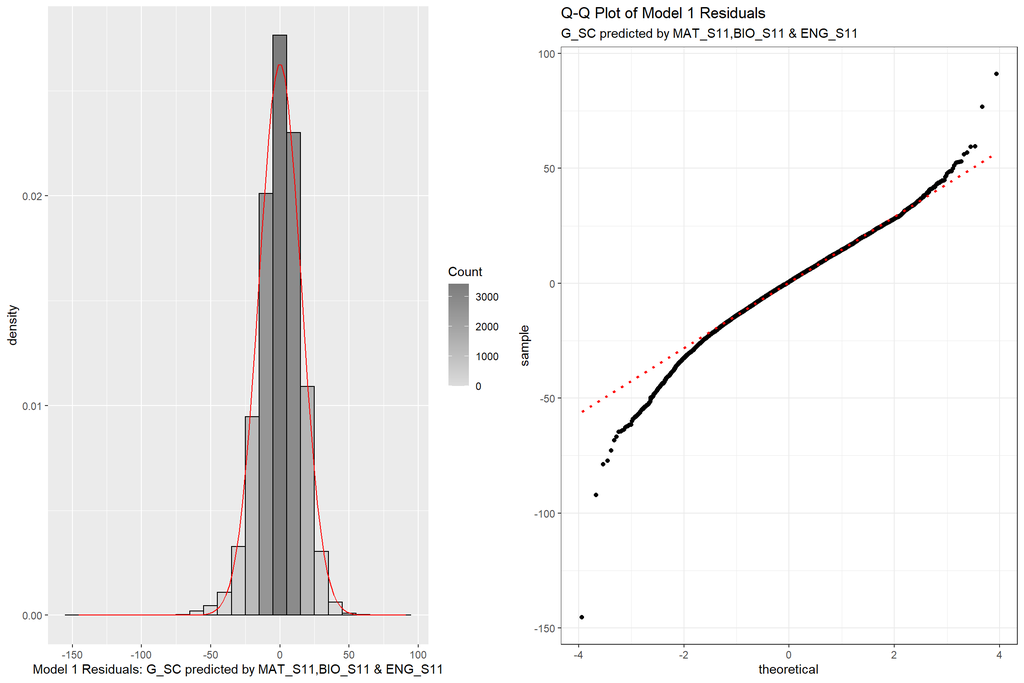

```r
############
# PART: Visualisation Histograms
############
# Plot single variable

binwidth <- 10
gs1 <- reg_model_1 %>% ggplot(aes(x = reg_model_1$residuals))
gs1 <- gs1 + geom_histogram(binwidth = binwidth, colour = "black", aes(y = ..density.., fill = ..count..))
gs1 <- gs1 + stat_function(fun = dnorm, color = "red", args = list(mean = model_1_stats$mean, sd = model_1_stats$std.dev), na.rm = TRUE)
gs1 <- gs1 + labs(x = "Model 1 Residuals: G_SC predicted by MAT_S11,BIO_S11 & ENG_S11")
gs1 <- gs1 + scale_fill_gradient("Count", low = "#DCDCDC", high = "#7C7C7C")


############
# PART: Visualisation Histograms Q-Q Plot
############

gs2 <- reg_model_1 %>% ggplot(aes(sample = reg_model_1$residuals)) +
  stat_qq() +
  stat_qq_line(linetype = "dotted", color = "red", size = 1) +
  theme_bw() +
  labs(title = "Q-Q Plot of Model 1 Residuals", subtitle = "G_SC predicted by MAT_S11,BIO_S11 & ENG_S11")


plot_grid(gs1, gs2, labels = "", ncol = 2)
```

##### 3.2.1.2.2 Influential observations

As well as testing for outliers, we also looked at whether certain cases exert undue influence over the parameters of the model. An influential observation is an observation that changes the slope of the line of best fit for our model. This type of analysis can help to determine whether the regression model is stable or if a few observations have a large bias on the fit of the model. Cook’s distance is a measure of the overall influence of a case on the model, and Cook and Weisberg (1982) suggests any value of 1 should be investigated. As mentioned we have no outliers with a cohens D greater than 1.

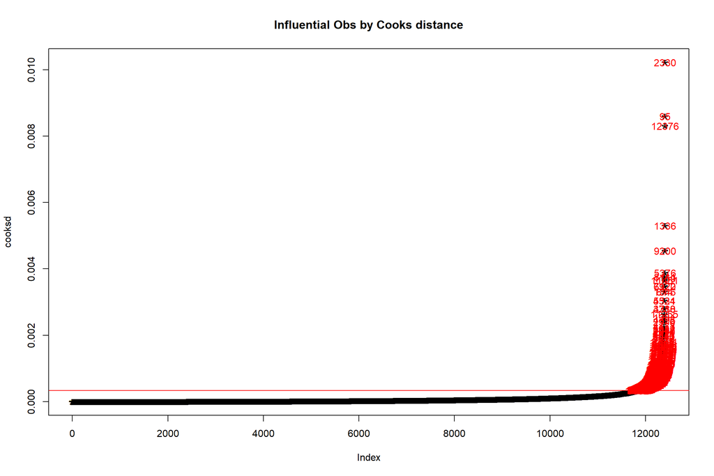

```r
############
# PART: Model 1 Check for Influential outliers
############
#--------------- Influential Outliers - Cook's distance ---------------#
cooksd<-sort(cooks.distance(reg_model_1))
# plot Cook's distance
plot(cooksd, pch="*", cex=2, main="Influential Obs by Cooks distance")
abline(h = 4*mean(cooksd, na.rm=T), col="red")  # add cutoff line
text(x = seq_along(cooksd) +1, y =cooksd, labels =ifelse(cooksd>4*mean(cooksd, na.rm =T), names(cooksd), ""), col ="red")  # add labels
```

```r
#--------------- find rows related to influential observations ---------------#
influential <- as.numeric(names(cooksd)[(cooksd > 4*mean(cooksd, na.rm=T))])  # influential row numbers
stem(influential)
```

```
##
##   The decimal point is 3 digit(s) to the right of the |
##
##    0 | 0000011111112222233445555556666777788888999
##    1 | 01111111112222222333333333445555566667778888899
##    2 | 0000111133333444556666778888999
##    3 | 000111233333444444455555567777777888888999
##    4 | 0001112222333333344444444445555555555556666667777778899999
##    5 | 000000111111222233333333333333444444556666666667777888999
##    6 | 000111222222334444444455555555567777777888999999
##    7 | 000011112222344445777888889999
##    8 | 00011234444555556666677777788899
##    9 | 0000000001111222222334444555666666666677777778889999
##   10 | 00011111223333444445556666677777888888999
##   11 | 000111112222222222222233333333334444444555555566677788999
##   12 | 00011111111111222233334444444
```

```r
head(tbl_sperf_sex_nat_diff[influential, ])  # influential observations.
```

|  | MAT_S11 | CR_S11 | CC_S11 | BIO_S11 | ENG_S11 | G_SC | GENDER | SCHOOL_NAT |
| --- | --- | --- | --- | --- | --- | --- | --- | --- |
| 1692 | 69 | 53 | 57 | 47 | 59 | 173 | F | PUBLIC |
| 5385 | 62 | 66 | 53 | 49 | 46 | 171 | F | PUBLIC |
| 9746 | 45 | 51 | 50 | 53 | 49 | 109 | F | PUBLIC |
| 793 | 50 | 45 | 50 | 55 | 46 | 105 | M | PRIVATE |
| 3753 | 53 | 44 | 50 | 65 | 55 | 122 | M | PUBLIC |
| 2818 | 100 | 74 | 81 | 92 | 82 | 225 | M | PRIVATE |

```r
car::outlierTest(reg_model_1) # Bonferonni p-value for most extreme obs - Are there any cases where the outcome variable has an unusual variable for its predictor values?
```

```
##        rstudent unadjusted p-value Bonferroni p
## 1336  -9.612358         8.4456e-22   1.0482e-17
## 7721  -6.087801         1.1785e-09   1.4627e-05
## 12376  6.008350         1.9268e-09   2.3913e-05
## 1237  -5.197996         2.0465e-07   2.5399e-03
## 3718  -5.095736         3.5250e-07   4.3749e-03
## 1281   5.067715         4.0841e-07   5.0688e-03
## 4534  -4.798271         1.6191e-06   2.0094e-02
```

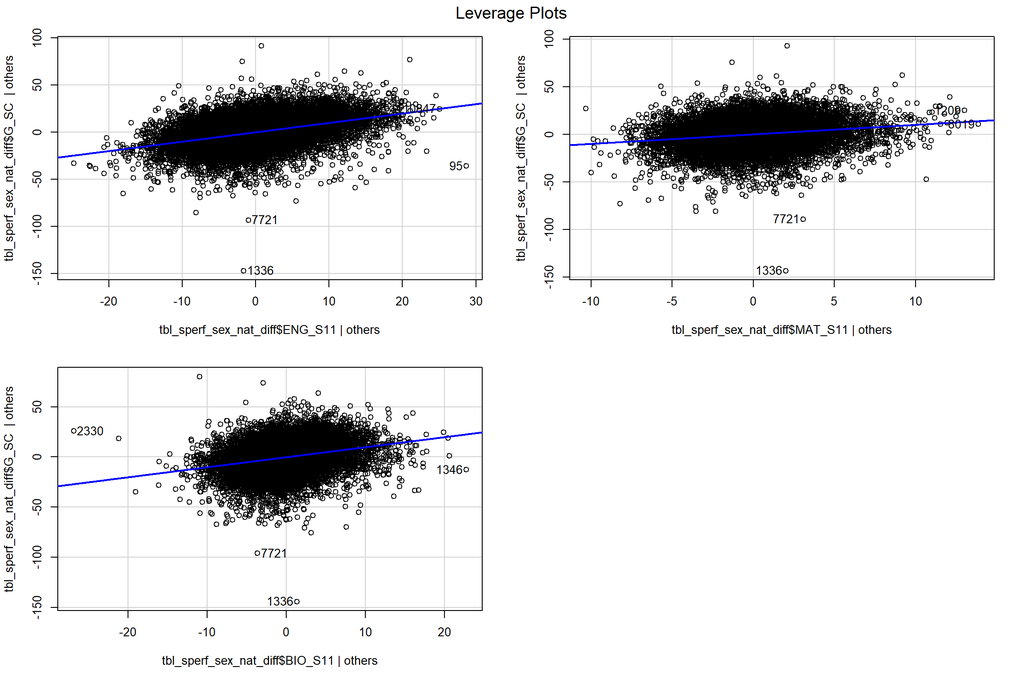

```r
car::leveragePlots(reg_model_1) # leverage plots
```

##### 3.2.1.2.3 Homoscedasticity of Residuals

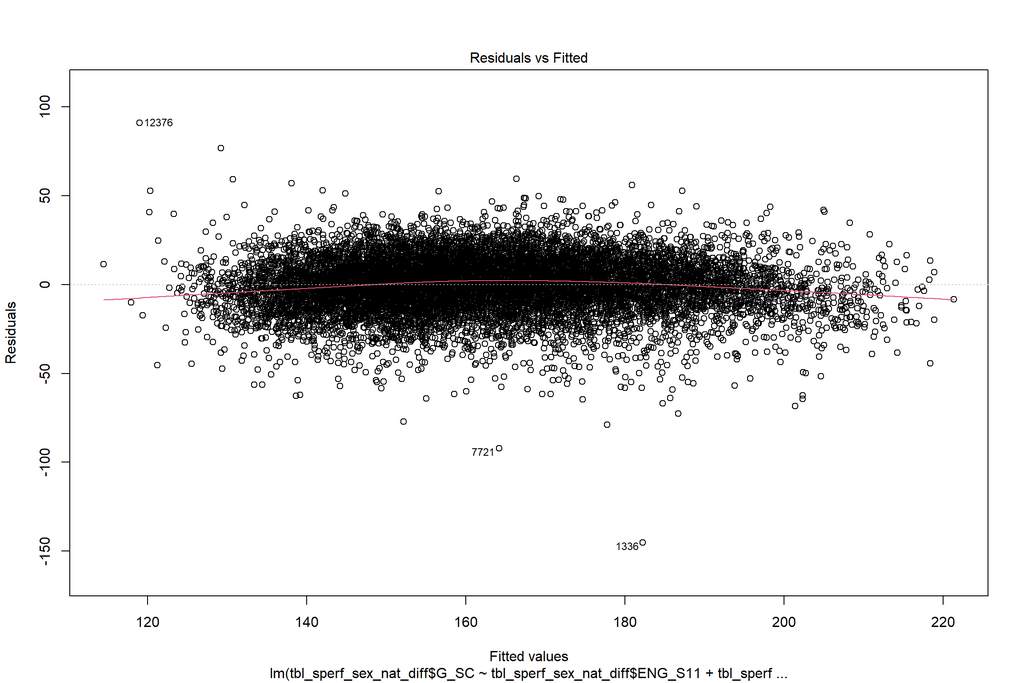

```r
############
# PART: Model 1 Check for homoscedasticity outliers
############
# --------------- residuals vs fitted values ---------- #
plot(reg_model_1, 1)
```

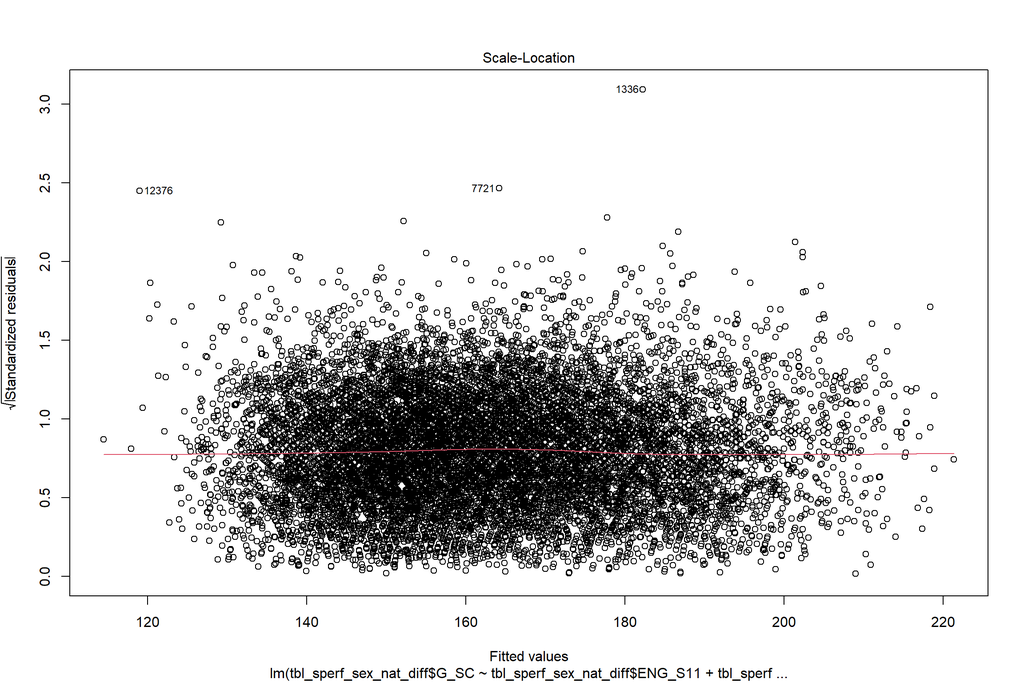

```r
# --------------- studentized residuals --------------- #
plot(reg_model_1, 3)
```

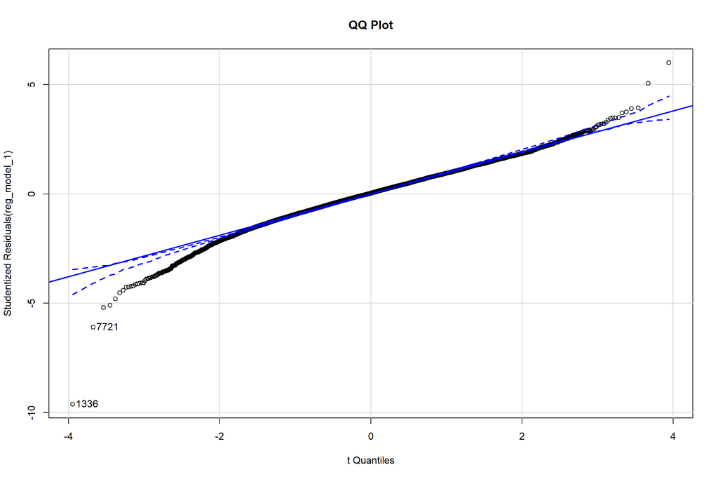

```
## [1] 1336 7721
```

```r
# --------------- Q-Q plot studentized residuals --------------- #
car::qqPlot(reg_model_1, main = "QQ Plot") #qq plot for studentized resid
```

```r
var_G_SC <- var(as.numeric(tbl_sperf_sex_nat_diff$G_SC, rm.na = TRUE)) %>% round(2)
```

##### 3.2.1.2.4 Collinearity of predictors

Collinearity exists when there is a strong correlation between two or more predictors in a regression model. It occurs when two or more independent variables contain strongly redundant information. We assess Collinearity by examining a correlation matrix that compares the predictor variables with each other. No correlation coefficient above 0.8 was found indicating no strong correlation is present. We also generated the variance inflation factor (VIF) for each predictor and found them to be all below 10 as suggested by Myers (1990). Related to the VIF is the tolerance statistic, which is its reciprocal (1/VIF). Lecture notes indicated that we should use the heuristic suggested by Tarling (2008).

> One should be concerned if VIF is above 2.5. (A VIF of 2.5 is equivalent to a tolerance of .4.)

As such, tests to see if the data met the assumption of collinearity indicated that multicollinearity was a concern for two predictors (Math highschool score, Tolerance = .39, VIF = 2.59; Biology highschool score, Tolerance = .39, VIF = 2.58)

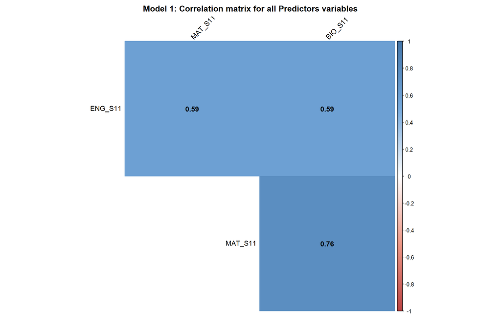

```r
### Correlation matrix for all
correlation_matrix <- tbl_sperf_sex_nat_diff %>%
        dplyr::select(ENG_S11,MAT_S11,BIO_S11) %>%
        as.matrix() %>%
        Hmisc::rcorr()

col <- colorRampPalette(c("#BB4444", "#EE9988", "#FFFFFF", "#77AADD", "#4477AA"))
title <- "Model 1: Correlation matrix for all Predictors variables"
gs <- corrplot::corrplot(correlation_matrix$r, method = "color", col = col(200), type = "upper", order = "hclust", addCoef.col = "black",              # Add coefficient of correlation
               tl.col                       = "black", tl.srt = 45,                                                                          #Text label color and rotation
               # Combine with significance
               p.mat                        = correlation_matrix$p, sig.level = 0.01, insig = "blank",
               # hide correlation coefficient on the principal diagonal
               diag                         = FALSE, title = title, mar = c(0, 0, 2, 0) ) # http://stackoverflow.com/a/14754408/54964)
```

```r
#------------Calculate Collinearity ------------#
vifmodel<-car::vif(reg_model_1) %>% as.data.frame()
colnames(vifmodel) <- 'VIF'
#Calculate tolerance
vifmodel$Tolerance <- 1/vifmodel$VIF
rownames(vifmodel) <- c('ENG_S11','MAT_S11','BIO_S11')

#-------- Pretty print my table -------#
vifmodel %>%
  kbl(caption = "Summary statistics for Residuals - Model 1") %>%
  kable_styling(bootstrap_options = c("striped", "hover"))
```

|  | VIF | Tolerance |
| --- | --- | --- |
| ENG_S11 | 1.667704 | 0.5996269 |
| MAT_S11 | 2.587270 | 0.3865077 |
| BIO_S11 | 2.579538 | 0.3876664 |

### 3.2.2 Reporting on Model 1

The following predictive model was generated:

$$\begin{equation}
G\_SC\ (Predicted) = 0.595*ENG\_S11 + 0.386*MAT\_S11 + 0.615*BIO\_S11 + 61.774
\tag{3.1}
\end{equation}$$

The relationship between high school maths score (MAT_S11), high school biology score (BIO_S11) high school engineering score (ENG_S11) and university final performance (G_SC) was modeled using a multiple linear model. The model was found to be statistically significant difference at the p < .001 level (F(3, 12407)= 5467, p<0.01). The model explains 57% of the variance in the outcome variable $R^2 = .569$.

Examination of the histogram, normal P-P plot of standardised residuals and the scatterplot of the dependent variable (final university score) and standardised residuals showed that some outliers existed. However, examination of the standardised residuals showed that none could be considered to have undue influence (95% within limits of +/1 1.96 and none with Cook’s distance > 1).

The scatterplot of standardised residuals showed that the data met the assumptions of homogeneity of variance and linearity. The data also meets the assumption of non-zero variances of the predictor. Examination for multicollinearity showed that the tolerance and variance influence factor measures were outside the acceptable levels (tolerance >0.4, VIF <2.5 ) as outlined in Tarling (2008).

## 3.3 Model 2

### 3.3.1 Multiple Linear Regression of student performance

As part of our assessment of model 1 (3.1) we determined that there is an issue with Collinearity of predictors. Math and Biology were found to have VIF statistic values of concern. As such, our second model is also a Multiple linear regression model with continuous scale predictors but with the Math variable removed. Math was removed from the model because it had the weaker effect size and in the model had a smaller coefficient.

> HA: Students who perform well overall in highschool will perform well in engineering at university.

In this model we have 2 predictor variables, student highschool scores in biology and engineering and 1 outcome variable, final university score.

#### 3.3.1.1 Step 1: Run Multiple Linear Regression

Given the assumptions of normality and that a positive correlation exists between the predictors and outcome variables, it is acceptable to use the dataset to build a predictive model.

```r
############
# PART: Multiple Linear Regression
############
# -------------- Regression --------------- #
reg_model_2 <-lm(tbl_sperf_sex_nat_diff$G_SC~tbl_sperf_sex_nat_diff$ENG_S11+tbl_sperf_sex_nat_diff$BIO_S11)

# -------------- Determine how good our model is versus using the mean --------------- #
stats::anova(reg_model_2) ## Get sums of squares of variability
```

|  | Df | Sum Sq | Mean Sq | F value | Pr(>F) |
| --- | --- | --- | --- | --- | --- |
| tbl_sperf_sex_nat_diff$ENG_S11 | 1 | 2906714.7 | 2906714.68 | 12202.323 | 0 |
| tbl_sperf_sex_nat_diff$BIO_S11 | 1 | 766833.1 | 766833.08 | 3219.148 | 0 |
| Residuals | 12408 | 2955709.1 | 238.21 | NA | NA |

```r
summary(reg_model_2)
```

```
##
## Call:
## lm(formula = tbl_sperf_sex_nat_diff$G_SC ~ tbl_sperf_sex_nat_diff$ENG_S11 +
##     tbl_sperf_sex_nat_diff$BIO_S11)
##
## Residuals:
##      Min       1Q   Median       3Q      Max
## -143.251   -9.336    0.596   10.143   93.047
##
## Coefficients:
##                                Estimate Std. Error t value Pr(>|t|)
## (Intercept)                    65.62757    0.82160   79.88   <2e-16 ***
## tbl_sperf_sex_nat_diff$ENG_S11  0.66522    0.01204   55.26   <2e-16 ***
## tbl_sperf_sex_nat_diff$BIO_S11  0.87524    0.01543   56.74   <2e-16 ***
## ---
## Signif. codes:  0 '***' 0.001 '**' 0.01 '*' 0.05 '.' 0.1 ' ' 1
##
## Residual standard error: 15.43 on 12408 degrees of freedom
## Multiple R-squared:  0.5541, Adjusted R-squared:  0.5541
## F-statistic:  7711 on 2 and 12408 DF,  p-value: < 2.2e-16
```

```r
stargazer(reg_model_1, reg_model_2,type ="text")
```

```
##
## =============================================================================
##                                        Dependent variable:
##                     ---------------------------------------------------------
##                                               G_SC
##                                 (1)                          (2)
## -----------------------------------------------------------------------------
## ENG_S11                       0.595***                     0.665***
##                               (0.012)                      (0.012)
##
## MAT_S11                       0.386***
##                               (0.018)
##
## BIO_S11                       0.615***                     0.875***
##                               (0.020)                      (0.015)
##
## Constant                     61.774***                    65.628***
##                               (0.828)                      (0.822)
##
## -----------------------------------------------------------------------------
## Observations                   12,411                       12,411
## R2                             0.569                        0.554
## Adjusted R2                    0.569                        0.554
## Residual Std. Error     15.169 (df = 12407)          15.434 (df = 12408)
## F Statistic         5,467.291*** (df = 3; 12407) 7,710.735*** (df = 2; 12408)
## =============================================================================
## Note:                                             *p<0.1; **p<0.05; ***p<0.01
```

#### 3.3.1.2 Step 2: Assessing the regression model: diagnostics

##### 3.3.1.2.1 Outliers and residuals

Based on the assessment below, we can assume normal distribution of residuals. We calculated standardised scores for skew and kurtosis and found both were outside our acceptable range of +/- 3.29. However, we found that 95% of values fell within 2 standard deviations (+/- 1.96) of our mean at a cut off value of 0.05. No records had a cooks d value greater than 1. We concluded the outliers will not have a significant effect on the usefulness of this model.

```r
############
# PART: check for outliers in our residuals
############
std_skew <- list()
std_kurt <- list()
gt_196 <- list()
gt_329 <- list()
#--------------- Check for percentage outliers ---------------#
variable <- "model2_stats"
st <- as.data.frame(pastecs::stat.desc(reg_model_2$residuals, basic = F))
model_2_stats <- st %>% data.table::transpose()
colnames(model_2_stats) <- rownames(st)
rownames(model_2_stats) <-('Model 2: Residuals')

## Build standard statistics
tpskew <- semTools::skew(reg_model_2$residuals)
tpkurt <- semTools::kurtosis(reg_model_2$residuals)
std_skew[[variable]] <- tpskew[1] / tpskew[2]
std_kurt[[variable]] <- tpkurt[1] / tpkurt[2]
z_score <- abs(scale(reg_model_2$residuals))
gt_196[[variable]] <- FSA::perc(as.numeric(z_score), 1.96, "gt") # 95% within +/- 1.96
gt_329[[variable]] <- FSA::perc(as.numeric(z_score), 3.29, "gt") # 99.7% within +- 3.29 for larger distributions
cooksd_gt_1 <- FSA::perc(as.numeric(cooks.distance(reg_model_2)), 1, "gt") # How many records are greater than 1.

## Build output
model_2_stats$std_skew <- std_skew
model_2_stats$std_kurt <- std_kurt
model_2_stats$gt_2sd <- gt_196
model_2_stats$gt_3sd <- gt_329
model_2_stats$cooksd_gt_1 <- cooksd_gt_1

#-------- Pretty print my table -------#
rbind(model_1_stats,model_2_stats) %>%
  kbl(caption = "Summary statistics for Residuals - Model 1 and Model 2") %>%
  kable_styling(bootstrap_options = c("striped", "hover"))
```

(#tab:Section 3 Model 2 Check for residual outliers)Summary statistics for Residuals - Model 1 and Model 2

|  | median | mean | SE.mean | CI.mean.0.95 | var | std.dev | coef.var | std_skew | std_kurt | gt_2sd | gt_3sd | cooksd_gt_1 |
| --- | --- | --- | --- | --- | --- | --- | --- | --- | --- | --- | --- | --- |
| Model 1: Residuals | 0.5212726 | 0 | 0.1361487 | 0.2668725 | 230.0560 | 15.16760 | -8.097244e+15 | -18.36887 | 39.7549 | 4.866651 | 0.5156716 | 0 |
| Model 2: Residuals | 0.5955142 | 0 | 0.1385293 | 0.2715389 | 238.1716 | 15.43281 | 2.031828e+16 | -17.03844 | 36.81116 | 4.955282 | 0.4753847 | 0 |

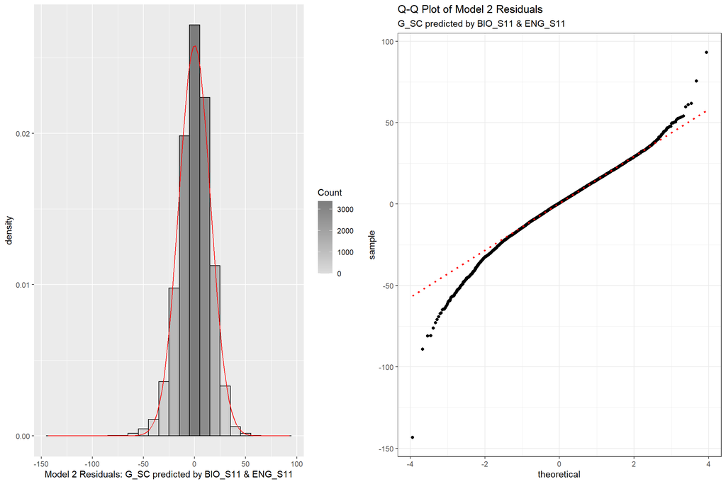

```r
############
# PART: Visualisation Histograms
############
# Plot single variable

binwidth <- 10
gs1 <- reg_model_2 %>% ggplot(aes(x = reg_model_2$residuals))
gs1 <- gs1 + geom_histogram(binwidth = binwidth, colour = "black", aes(y = ..density.., fill = ..count..))
gs1 <- gs1 + stat_function(fun = dnorm, color = "red", args = list(mean = model_2_stats$mean, sd = model_2_stats$std.dev), na.rm = TRUE)
gs1 <- gs1 + labs(x = "Model 2 Residuals: G_SC predicted by BIO_S11 & ENG_S11")
gs1 <- gs1 + scale_fill_gradient("Count", low = "#DCDCDC", high = "#7C7C7C")


############
# PART: Visualisation Histograms Q-Q Plot
############

gs2 <- reg_model_2 %>% ggplot(aes(sample = reg_model_2$residuals)) +
  stat_qq() +
  stat_qq_line(linetype = "dotted", color = "red", size = 1) +
  theme_bw() +
  labs(title = "Q-Q Plot of Model 2 Residuals", subtitle = "G_SC predicted by BIO_S11 & ENG_S11")


plot_grid(gs1, gs2, labels = "", ncol = 2)
```

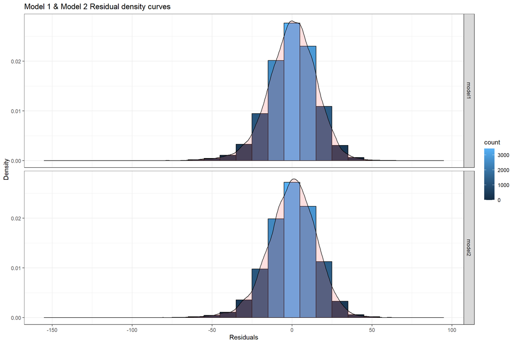

```r
############
# PART: Visualisation of density together
############
## http://www.sthda.com/english/wiki/ggplot2-density-plot-quick-start-guide-r-software-and-data-visualization


gs <- cbind(model1 = resid(reg_model_1),model2 = resid(reg_model_2)) %>%
      as.data.frame() %>%
      gather(model1, model2, key = "var", value = "value") %>%
      ggplot(aes(x = value)) +
      geom_histogram(binwidth = binwidth, colour = "black", aes(y = ..density.., fill = ..count..)) +
        geom_density(alpha = .2, fill = "#FF6666") +
        facet_grid(var ~ .) +
        theme_bw() +
        labs(title = "Model 1 & Model 2 Residual density curves", x = "Residuals", y = "Density")

show(gs)
```

##### 3.3.1.2.2 Influential observations

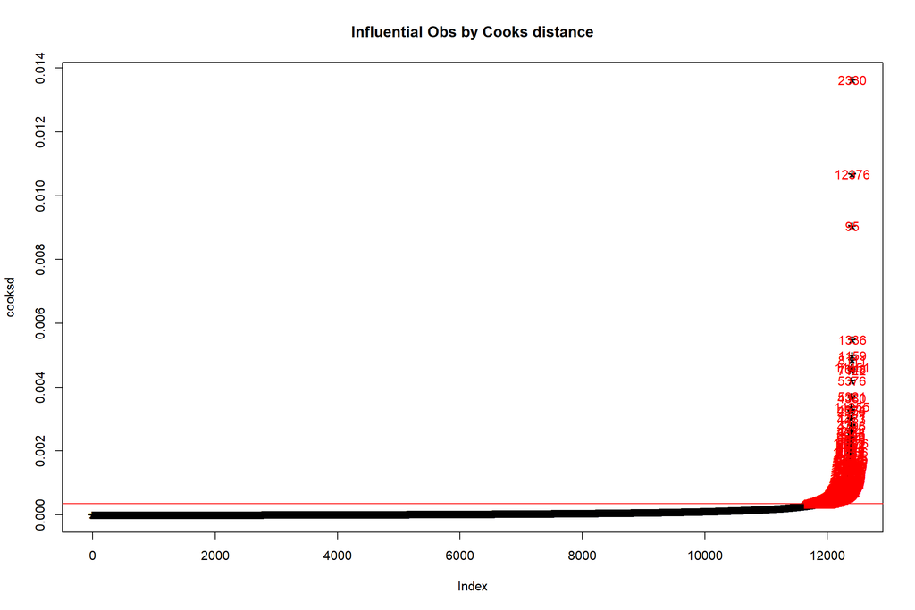

```r
############
# PART: Model 2 Check for Influential outliers
############
#--------------- Influential Outliers - Cook's distance ---------------#
cooksd<-sort(cooks.distance(reg_model_2))
# plot Cook's distance
plot(cooksd, pch="*", cex=2, main="Influential Obs by Cooks distance")
abline(h = 4*mean(cooksd, na.rm=T), col="red")  # add cutoff line
text(x = seq_along(cooksd) +1, y =cooksd, labels =ifelse(cooksd>4*mean(cooksd, na.rm =T), names(cooksd), ""), col ="red")  # add labels
```

```r
#--------------- find rows related to influential observations ---------------#
influential <- as.numeric(names(cooksd)[(cooksd > 4*mean(cooksd, na.rm=T))])  # influential row numbers
stem(influential)
```

```
##
##   The decimal point is 3 digit(s) to the right of the |
##
##    0 | 00000111111111222222334455555666677778888889999
##    1 | 000011111111122222233333334445555556666788888899999
##    2 | 0001111133333444455567888999
##    3 | 0000112333333344444555555556777777888999
##    4 | 000011122223333344444444445555555555555555666667777788888999
##    5 | 0000001111112222333333333345556666666667788889
##    6 | 00000111122222222334444455555556677777778888889999999
##    7 | 000000111122234445577778888899
##    8 | 0000011122234445555556666666777789999
##    9 | 0000011122222333344555556666666667778899999
##   10 | 00111112222233334444445566667777888888999
##   11 | 000111111122222222222223333333333444445555555566677778999
##   12 | 00011111111111222333333344444444
```

```r
head(tbl_sperf_sex_nat_diff[influential, ])  # influential observations.
```

|  | MAT_S11 | CR_S11 | CC_S11 | BIO_S11 | ENG_S11 | G_SC | GENDER | SCHOOL_NAT |
| --- | --- | --- | --- | --- | --- | --- | --- | --- |
| 8688 | 50 | 35 | 43 | 51 | 48 | 107 | M | PUBLIC |
| 1916 | 51 | 54 | 42 | 48 | 48 | 108 | M | PUBLIC |
| 4436 | 71 | 86 | 87 | 74 | 90 | 215 | M | PRIVATE |
| 10833 | 53 | 52 | 53 | 49 | 59 | 178 | M | PUBLIC |
| 3882 | 47 | 49 | 52 | 48 | 46 | 107 | M | PRIVATE |
| 9753 | 51 | 55 | 58 | 65 | 55 | 113 | F | PUBLIC |

```r
car::outlierTest(reg_model_2) # Bonferonni p-value for most extreme obs - Are there any cases where the outcome variable has an unusual variable for its predictor values?
```

```
##        rstudent unadjusted p-value Bonferroni p
## 1336  -9.314410         1.4311e-20   1.7761e-16
## 12376  6.039963         1.5856e-09   1.9679e-05
## 7721  -5.783051         7.5127e-09   9.3240e-05
## 1237  -5.259156         1.4712e-07   1.8260e-03
## 3718  -5.237901         1.6507e-07   2.0487e-03
## 4534  -4.946987         7.6359e-07   9.4769e-03
## 1281   4.894858         9.9614e-07   1.2363e-02
## 95    -4.731101         2.2577e-06   2.8020e-02
```

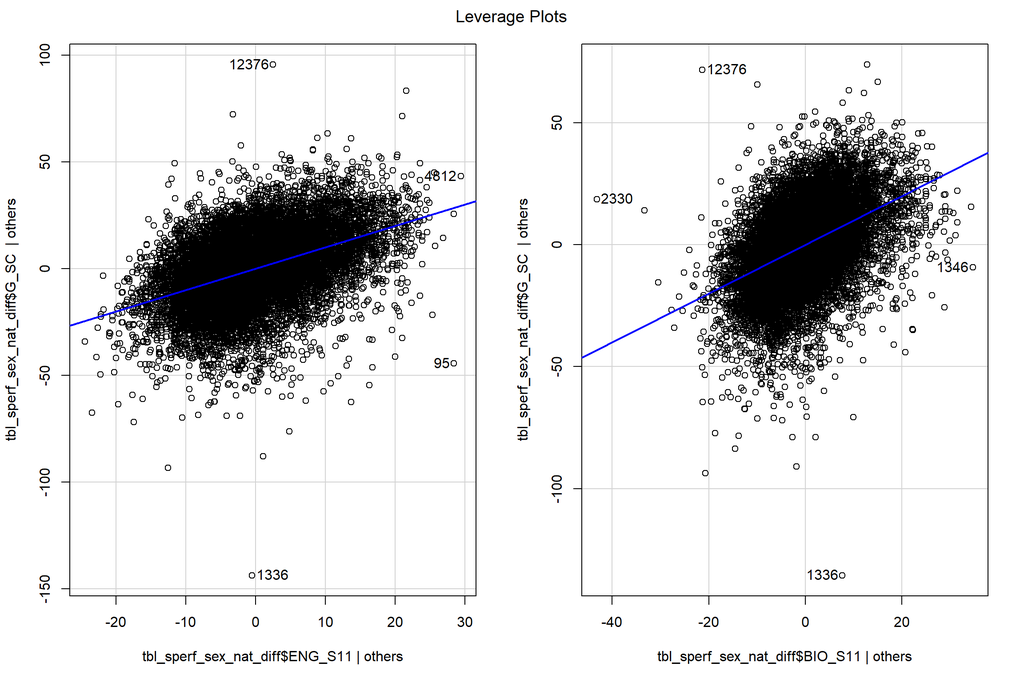

```r
car::leveragePlots(reg_model_2) # leverage plots
```

##### 3.3.1.2.3 Homoscedasticity of Residuals

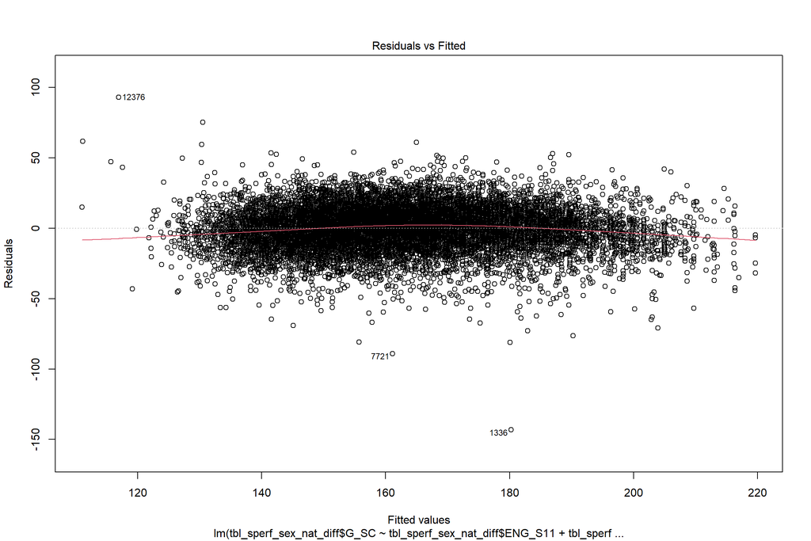

```r
############
# PART: Model 2 Check for homoscedasticity outliers
############
# --------------- residuals vs fitted values ---------- #
plot(reg_model_2, 1)
```

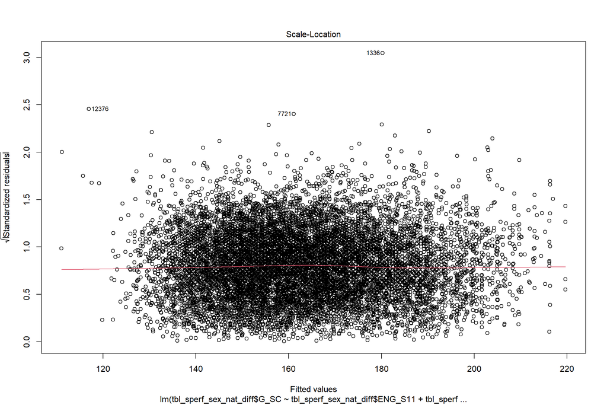

```r
# --------------- studentized residuals --------------- #
plot(reg_model_2, 3)
```

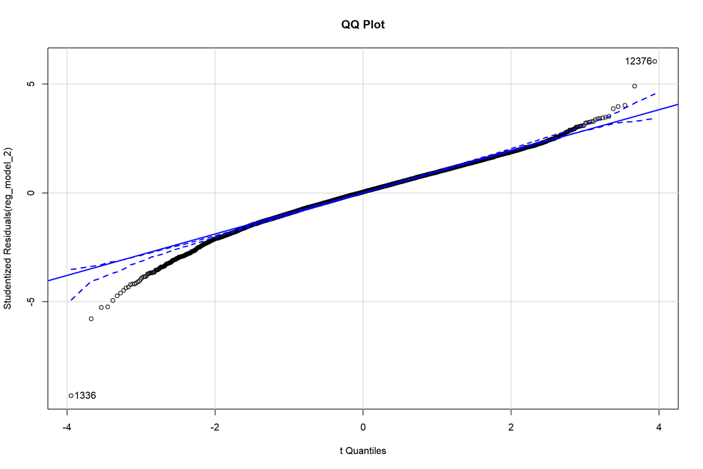

```
## [1]  1336 12376
```

```r
# --------------- Q-Q plot studentized residuals --------------- #
car::qqPlot(reg_model_2, main = "QQ Plot") #qq plot for studentized resid
```

```r
## already reported on in section 2.
var_G_SC <- var(as.numeric(tbl_sperf_sex_nat_diff$G_SC, rm.na = TRUE)) %>% round(2)
var_MAT_S11 <- var(as.numeric(tbl_sperf_sex_nat_diff$BIO_S11, rm.na = TRUE)) %>% round(2)
var_ENG_S11 <- var(as.numeric(tbl_sperf_sex_nat_diff$ENG_S11, rm.na = TRUE)) %>% round(2)
```

##### 3.3.1.2.4 Collinearity of predictors

No correlation coefficient above 0.8 was found, indicating no strong correlation is present. We also generated the variance inflation factor (VIF) for each predictor and found them to be all below 10 as suggested by Myers (1990). Related to the VIF is the tolerance statistic, which is its reciprocal (1/VIF). Tests to see if the data met the assumption of collinearity indicated that multicollinearity was not concern for the two predictors (Biology highschool score, Tolerance = .65, VIF = 1.54; Engineering highschool score, Tolerance = .65, VIF = 1.54)

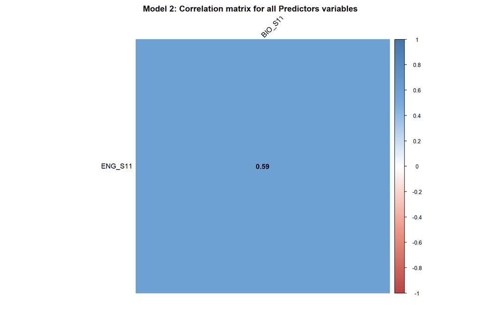

```r
### Correlation matrix for all
correlation_matrix <- tbl_sperf_sex_nat_diff %>%
        select(ENG_S11,BIO_S11) %>%
        as.matrix() %>%
        Hmisc::rcorr()

col <- colorRampPalette(c("#BB4444", "#EE9988", "#FFFFFF", "#77AADD", "#4477AA"))
title <- "Model 2: Correlation matrix for all Predictors variables"
gs <- corrplot::corrplot(correlation_matrix$r, method = "color", col = col(200), type = "upper", order = "hclust", addCoef.col = "black",              # Add coefficient of correlation
               tl.col                       = "black", tl.srt = 45,                                                                          #Text label color and rotation
               # Combine with significance
               p.mat                        = correlation_matrix$p, sig.level = 0.01, insig = "blank",
               # hide correlation coefficient on the principal diagonal
               diag                         = FALSE, title = title, mar = c(0, 0, 2, 0) ) # http://stackoverflow.com/a/14754408/54964)
```

```r
#------------Calculate Collinearity ------------#
vifmodel<-car::vif(reg_model_2) %>% as.data.frame()
colnames(vifmodel) <- 'VIF'
#Calculate tolerance
vifmodel$Tolerance <- 1/vifmodel$VIF
rownames(vifmodel) <- c('ENG_S11','BIO_S11')

#-------- Pretty print my table -------#
vifmodel %>%
  kbl(caption = "Summary statistics for Residuals - Model 2") %>%
  kable_styling(bootstrap_options = c("striped", "hover"))
```

|  | VIF | Tolerance |
| --- | --- | --- |
| ENG_S11 | 1.543145 | 0.6480273 |
| BIO_S11 | 1.543145 | 0.6480273 |

### 3.3.2 Reporting on Model 2

The following predictive model was generated:

$$\begin{equation}
G\_SC\ (Predicted) = 0.665*ENG\_S11 + 0.875*BIO\_S11 + 65.628
\tag{3.2}
\end{equation}$$

The relationship between high school biology score (BIO_S11), high school engineering score (ENG_S11) and university final performance (G_SC) was modeled using a multiple linear model. The model was found to be statistically significant difference at the p < .001 level (F(2, 12408)= 7,711, p<0.01). The model explains 55% of the variance in the outcome variable $Adjusted R^2 = .0.554$.

The individual predictors were examined further and indicated that Engineering (t = 55.26, p < .001), Biology (t = 56.74, p < .001) scores at the end of highschool were significant predictors in the model.

Examination of the histogram, normal P-P plot of standardised residuals and the scatterplot of the dependent variable, final university score, and standardised residuals showed that some outliers existed. However, examination of the standardised residuals showed that none could be considered to have undue influence (95% within limits of +/1 1.96 and none with Cook’s distance > 1).

The scatterplot of standardised residuals showed that the data met the assumptions of homogeneity of variance and linearity. The data also meets the assumption of non-zero variances of the predictor. Examination for multicollinearity showed that the tolerance and variance influence factor measures were within the acceptable levels (tolerance >0.4, VIF <2.5 ) as outlined in Tarling (2008).

The assumptions of causality are given due to the nature of the conceptual framework of the statistical analysis. Students attend highschool before university. Similarly independence is assured since each student is unique and each evaluation independently assessed.

## 3.4 Model 3

### 3.4.1 Multiple Linear Regression using school nature and subject interaction terms

> HA: Students who attend private high schools will perform better overall in engineering at university.

In this model we use 2 continuous scale predictor variables, student highschool scores in biology and engineering and 1 outcome variable and 1 categorical predictor, school nature.

#### 3.4.1.1 Step 1: Run Multiple Linear Regression

We transformed schooling type into an interactive variable, where public school was treated as the reference category/baseline and private school was treated as the category of interest. This means in our model public school was given the value of 0 and private school the value of 1. Both the switch, and the interaction variable are included because the switch variable determines the inception point of the model with the Y axis (the starting point) while the interaction determines the slope of the line.

```r
############
# PART: Multiple Linear Regression
############
# -------------- create interaction term --------------- #
tbl_sperf_sex_nat_diff$school_switch <- as.integer(tbl_sperf_sex_nat_diff$SCHOOL_NAT == 'PRIVATE')
tbl_sperf_sex_nat_diff$int_bio_school_private <- tbl_sperf_sex_nat_diff$BIO_S11*tbl_sperf_sex_nat_diff$school_switch
tbl_sperf_sex_nat_diff$int_eng_school_private <- tbl_sperf_sex_nat_diff$ENG_S11*tbl_sperf_sex_nat_diff$school_switch

# -------------- Regression --------------- #
reg_model_3 <-lm(tbl_sperf_sex_nat_diff$G_SC~tbl_sperf_sex_nat_diff$ENG_S11+
        tbl_sperf_sex_nat_diff$BIO_S11 +
        tbl_sperf_sex_nat_diff$int_bio_school_private +
        tbl_sperf_sex_nat_diff$int_eng_school_private +
        tbl_sperf_sex_nat_diff$school_switch
)

# -------------- Determine how good our model is versus using the mean --------------- #
stats::anova(reg_model_3) ## Get sums of squares of variability
```

|  | Df | Sum Sq | Mean Sq | F value | Pr(>F) |
| --- | --- | --- | --- | --- | --- |
| tbl_sperf_sex_nat_diff$ENG_S11 | 1 | 2.906715e+06 | 2.906715e+06 | 1.223727e+04 | 0.000000e+00 |
| tbl_sperf_sex_nat_diff$BIO_S11 | 1 | 7.668331e+05 | 7.668331e+05 | 3.228368e+03 | 0.000000e+00 |
| tbl_sperf_sex_nat_diff$int_bio_school_private | 1 | 5.545686e-01 | 5.545686e-01 | 2.334734e-03 | 9.614627e-01 |
| tbl_sperf_sex_nat_diff$int_eng_school_private | 1 | 2.295532e+02 | 2.295532e+02 | 9.664190e-01 | 3.255941e-01 |
| tbl_sperf_sex_nat_diff$school_switch | 1 | 8.923603e+03 | 8.923603e+03 | 3.756838e+01 | 9.094128e-10 |
| Residuals | 12405 | 2.946555e+06 | 2.375297e+02 | NA | NA |

```r
summary(reg_model_3)
```

```
##
## Call:
## lm(formula = tbl_sperf_sex_nat_diff$G_SC ~ tbl_sperf_sex_nat_diff$ENG_S11 +
##     tbl_sperf_sex_nat_diff$BIO_S11 + tbl_sperf_sex_nat_diff$int_bio_school_private +
##     tbl_sperf_sex_nat_diff$int_eng_school_private + tbl_sperf_sex_nat_diff$school_switch)
##
## Residuals:
##      Min       1Q   Median       3Q      Max
## -142.624   -9.332    0.637   10.094   95.878
##
## Coefficients:
##                                               Estimate Std. Error t value
## (Intercept)                                   59.88960    1.28287  46.684
## tbl_sperf_sex_nat_diff$ENG_S11                 0.68671    0.02186  31.408
## tbl_sperf_sex_nat_diff$BIO_S11                 0.94658    0.02247  42.133
## tbl_sperf_sex_nat_diff$int_bio_school_private -0.13926    0.03091  -4.505
## tbl_sperf_sex_nat_diff$int_eng_school_private -0.02519    0.02709  -0.930
## tbl_sperf_sex_nat_diff$school_switch          10.60262    1.72982   6.129
##                                               Pr(>|t|)
## (Intercept)                                    < 2e-16 ***
## tbl_sperf_sex_nat_diff$ENG_S11                 < 2e-16 ***
## tbl_sperf_sex_nat_diff$BIO_S11                 < 2e-16 ***
## tbl_sperf_sex_nat_diff$int_bio_school_private 6.70e-06 ***
## tbl_sperf_sex_nat_diff$int_eng_school_private    0.352
## tbl_sperf_sex_nat_diff$school_switch          9.09e-10 ***
## ---
## Signif. codes:  0 '***' 0.001 '**' 0.01 '*' 0.05 '.' 0.1 ' ' 1
##
## Residual standard error: 15.41 on 12405 degrees of freedom
## Multiple R-squared:  0.5555, Adjusted R-squared:  0.5553
## F-statistic:  3101 on 5 and 12405 DF,  p-value: < 2.2e-16
```

```r
stargazer(reg_model_1, reg_model_2,reg_model_3, type ="text")
```

```
##
## =============================================================================================================
##                                                         Dependent variable:
##                        --------------------------------------------------------------------------------------
##                                                                 G_SC
##                                    (1)                          (2)                          (3)
## -------------------------------------------------------------------------------------------------------------
## ENG_S11                          0.595***                     0.665***                     0.687***
##                                  (0.012)                      (0.012)                      (0.022)
##
## MAT_S11                          0.386***
##                                  (0.018)
##
## BIO_S11                          0.615***                     0.875***                     0.947***
##                                  (0.020)                      (0.015)                      (0.022)
##
## int_bio_school_private                                                                    -0.139***
##                                                                                            (0.031)
##
## int_eng_school_private                                                                      -0.025
##                                                                                            (0.027)
##
## school_switch                                                                             10.603***
##                                                                                            (1.730)
##
## Constant                        61.774***                    65.628***                    59.890***
##                                  (0.828)                      (0.822)                      (1.283)
##
## -------------------------------------------------------------------------------------------------------------
## Observations                      12,411                       12,411                       12,411
## R2                                0.569                        0.554                        0.556
## Adjusted R2                       0.569                        0.554                        0.555
## Residual Std. Error        15.169 (df = 12407)          15.434 (df = 12408)          15.412 (df = 12405)
## F Statistic            5,467.291*** (df = 3; 12407) 7,710.735*** (df = 2; 12408) 3,100.835*** (df = 5; 12405)
## =============================================================================================================
## Note:                                                                             *p<0.1; **p<0.05; ***p<0.01
```

#### 3.4.1.2 Step 2: Assessing the regression model: diagnostics

##### 3.4.1.2.1 Outliers and residuals

Based on the assessment below we can assume a normal distribution of residuals. We calculated standardised scores for skew and kurtosis and found both were outside our acceptable range of +/- 3.29. However we found that 95% of values fell within 2 standard deviations (+/- 1.96) of our mean at a cut off value of 0.05. No records had a cooks d value greater than 1. We concluded the outliers will not have a significant effect on the usefulness of this model.

```r
############
# PART: check for outliers in our residuals
############
std_skew <- list()
std_kurt <- list()
gt_196 <- list()
gt_329 <- list()
#--------------- Check for percentage outliers ---------------#
variable <- "model3_stats"
st <- as.data.frame(pastecs::stat.desc(reg_model_3$residuals, basic = F))
model_3_stats <- st %>% data.table::transpose()
colnames(model_3_stats) <- rownames(st)
rownames(model_3_stats) <-('Model 3: Residuals')

## Build standard statistics
tpskew <- semTools::skew(reg_model_3$residuals)
tpkurt <- semTools::kurtosis(reg_model_3$residuals)
std_skew[[variable]] <- tpskew[1] / tpskew[2]
std_kurt[[variable]] <- tpkurt[1] / tpkurt[2]
z_score <- abs(scale(reg_model_3$residuals))
gt_196[[variable]] <- FSA::perc(as.numeric(z_score), 1.96, "gt") # 95% within +/- 1.96
gt_329[[variable]] <- FSA::perc(as.numeric(z_score), 3.29, "gt") # 99.7% within +- 3.29 for larger distributions
cooksd_gt_1 <- FSA::perc(as.numeric(cooks.distance(reg_model_3)), 1, "gt") # How many records are greater than 1.

## Build output
model_3_stats$std_skew <- std_skew
model_3_stats$std_kurt <- std_kurt
model_3_stats$gt_2sd <- gt_196
model_3_stats$gt_3sd <- gt_329
model_3_stats$cooksd_gt_1 <- cooksd_gt_1

#-------- Pretty print my table -------#
rbind(model_1_stats,model_2_stats, model_3_stats) %>%
  kbl(caption = "Summary statistics for Residuals - Model 1, Model 2 & Model 3") %>%
  kable_styling(bootstrap_options = c("striped", "hover"))
```

(#tab:Section 3 Model 3 Check for residual outliers)Summary statistics for Residuals - Model 1, Model 2 & Model 3

|  | median | mean | SE.mean | CI.mean.0.95 | var | std.dev | coef.var | std_skew | std_kurt | gt_2sd | gt_3sd | cooksd_gt_1 |
| --- | --- | --- | --- | --- | --- | --- | --- | --- | --- | --- | --- | --- |
| Model 1: Residuals | 0.5212726 | 0 | 0.1361487 | 0.2668725 | 230.0560 | 15.16760 | -8.097244e+15 | -18.36887 | 39.7549 | 4.866651 | 0.5156716 | 0 |
| Model 2: Residuals | 0.5955142 | 0 | 0.1385293 | 0.2715389 | 238.1716 | 15.43281 | 2.031828e+16 | -17.03844 | 36.81116 | 4.955282 | 0.4753847 | 0 |
| Model 3: Residuals | 0.6366954 | 0 | 0.1383146 | 0.2711181 | 237.4340 | 15.40889 | -2.249774e+16 | -16.87295 | 37.04032 | 4.906937 | 0.4834421 | 0 |

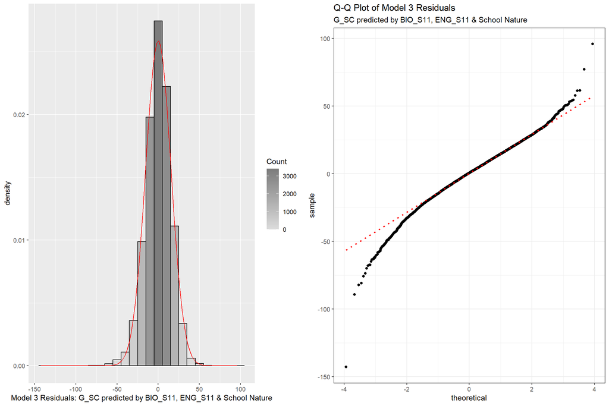

```r
############
# PART: Visualisation Histograms
############
# Plot single variable

binwidth <- 10
gs1 <- reg_model_3 %>% ggplot(aes(x = reg_model_3$residuals))
gs1 <- gs1 + geom_histogram(binwidth = binwidth, colour = "black", aes(y = ..density.., fill = ..count..))
gs1 <- gs1 + stat_function(fun = dnorm, color = "red", args = list(mean = model_3_stats$mean, sd = model_3_stats$std.dev), na.rm = TRUE)
gs1 <- gs1 + labs(x = "Model 3 Residuals: G_SC predicted by BIO_S11, ENG_S11 & School Nature")
gs1 <- gs1 + scale_fill_gradient("Count", low = "#DCDCDC", high = "#7C7C7C")


############
# PART: Visualisation Histograms Q-Q Plot
############

gs2 <- reg_model_3 %>% ggplot(aes(sample = reg_model_3$residuals)) +
  stat_qq() +
  stat_qq_line(linetype = "dotted", color = "red", size = 1) +
  theme_bw() +
  labs(title = "Q-Q Plot of Model 3 Residuals", subtitle = "G_SC predicted by BIO_S11, ENG_S11 & School Nature")


plot_grid(gs1, gs2, labels = "", ncol = 2)
```

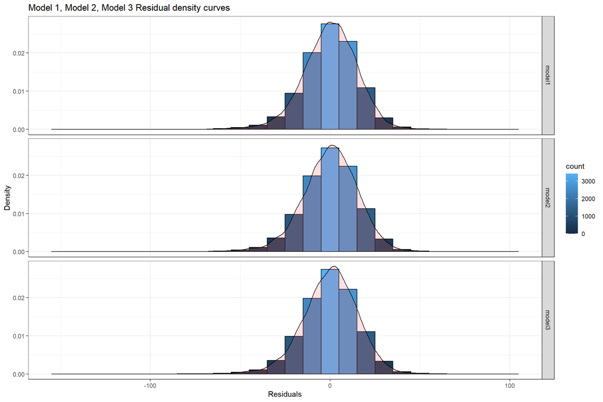

```r
############
# PART: Visualisation of density together
############
## http://www.sthda.com/english/wiki/ggplot2-density-plot-quick-start-guide-r-software-and-data-visualization


gs <- cbind(model1 = resid(reg_model_1),model2 = resid(reg_model_2), model3 = resid(reg_model_3)) %>%
      as.data.frame() %>%
      gather(model1, model2,model3, key = "var", value = "value") %>%
      ggplot(aes(x = value)) +
      geom_histogram(binwidth = binwidth, colour = "black", aes(y = ..density.., fill = ..count..)) +
        geom_density(alpha = .2, fill = "#FF6666") +
        facet_grid(var ~ .) +
        theme_bw() +
        labs(title = "Model 1, Model 2, Model 3 Residual density curves", x = "Residuals", y = "Density")

show(gs)
```

##### 3.4.1.2.2 Influential observations

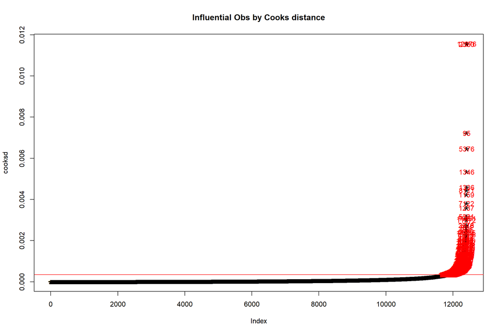

```r
############
# PART: Model 3 Check for Influential outliers
############
#--------------- Influential Outliers - Cook's distance ---------------#
cooksd<-sort(cooks.distance(reg_model_3))
# plot Cook's distance
plot(cooksd, pch="*", cex=2, main="Influential Obs by Cooks distance")
abline(h = 4*mean(cooksd, na.rm=T), col="red")  # add cutoff line
text(x = seq_along(cooksd) +1, y =cooksd, labels =ifelse(cooksd>4*mean(cooksd, na.rm =T), names(cooksd), ""), col ="red")  # add labels
```

```r
#--------------- find rows related to influential observations ---------------#
influential <- as.numeric(names(cooksd)[(cooksd > 4*mean(cooksd, na.rm=T))])  # influential row numbers
stem(influential)
```

```
##
##   The decimal point is 3 digit(s) to the right of the |
##
##    0 | 000011112222222333445555555566666777777888888888999
##    1 | 00001111111112222233333333344444555555666667788888889999
##    2 | 000111111112333344445557888899999
##    3 | 00001111333333444445555555566777777888999
##    4 | 000000111222233334444444555555555566666777788888999
##    5 | 0000001111111222333333333334445566666666777888
##    6 | 0000011222222333444444555556666777777778888999999
##    7 | 000011122234445566777788888999
##    8 | 00000011112223344445555555666666667778899999
##    9 | 0000011111222233334444455555666666666777788999999
##   10 | 0011112222333444444555566666677777888888999
##   11 | 00011111222222222222333333333344445555555666777889999
##   12 | 0000111111122333334444444
```

```r
head(tbl_sperf_sex_nat_diff[influential, ])  # influential observations.
```

|  | MAT_S11 | CR_S11 | CC_S11 | BIO_S11 | ENG_S11 | G_SC | GENDER | SCHOOL_NAT | school_switch | int_bio_school_private | int_eng_school_private |
| --- | --- | --- | --- | --- | --- | --- | --- | --- | --- | --- | --- |
| 9051 | 67 | 74 | 70 | 67 | 80 | 217 | F | PRIVATE | 1 | 67 | 80 |
| 4151 | 47 | 51 | 52 | 42 | 46 | 111 | M | PRIVATE | 1 | 42 | 46 |
| 6167 | 81 | 64 | 67 | 68 | 76 | 128 | M | PRIVATE | 1 | 68 | 76 |
| 2094 | 49 | 38 | 42 | 44 | 46 | 111 | F | PRIVATE | 1 | 44 | 46 |
| 10666 | 53 | 66 | 65 | 48 | 50 | 172 | F | PRIVATE | 1 | 48 | 50 |
| 8468 | 45 | 43 | 43 | 43 | 52 | 115 | M | PRIVATE | 1 | 43 | 52 |

```r
car::outlierTest(reg_model_3) # Bonferonni p-value for most extreme obs - Are there any cases where the outcome variable has an unusual variable for its predictor values?
```

```
##        rstudent unadjusted p-value Bonferroni p
## 1336  -9.287332         1.8431e-20   2.2874e-16
## 12376  6.236049         4.6334e-10   5.7505e-06
## 7721  -5.792989         7.0824e-09   8.7899e-05
## 1237  -5.340156         9.4506e-08   1.1729e-03
## 3718  -5.252836         1.5225e-07   1.8896e-03
## 1281   5.019213         5.2603e-07   6.5286e-03
## 4534  -4.922259         8.6651e-07   1.0754e-02
## 95    -4.775736         1.8110e-06   2.2476e-02
```

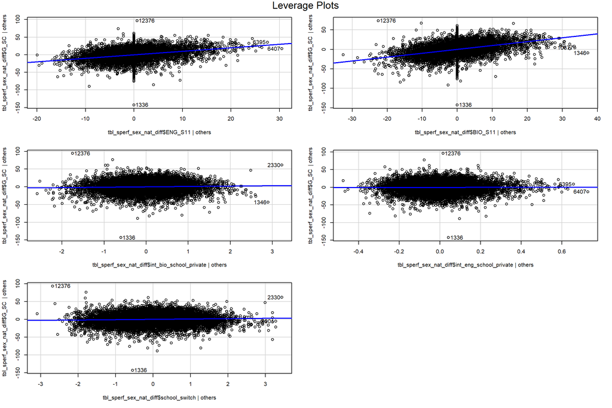

```r
car::leveragePlots(reg_model_3) # leverage plots
```